# Phosphoroteomics MAXOMOD

Clara Meijs

2024-01-31

## Loading the libraries

Start with clearing environment and loading packages

```r
set.seed(9)
rm(list=ls())

 library(pheatmap)
 library(ggplot2)
 library(matrixStats)
 library(wesanderson)
 library(clusterProfiler)
 library(enrichplot)
 library(msigdbr)
 library(dichromat)
 library(stringr)
 library(dplyr)
 library(ggrepel)
 library(reshape2)
 library(umap)
 library(ggthemes)
 library(cowplot)
 library(DEP)
 library(naniar)
 library(SummarizedExperiment)
 library(data.table)
 library(org.Hs.eg.db)
```

## Set working directories

```r
# if you are using Rstudio run the following command, otherwise, set the working directory to the folder where this script is in
setwd(dirname(rstudioapi::getActiveDocumentContext()$path))

# create directory for results
dir.create(file.path(getwd(),'results'), showWarnings = FALSE)
# create directory for plots
dir.create(file.path(getwd(),'plots'), showWarnings = FALSE)
```

## Load data

```r
#load expression data
      phpr_data <- read.delim("data/Phospho (STY)Sites_pCSF_08.2023.txt")

      Intensity_names = colnames(phpr_data)[grep("Intensity.", colnames(phpr_data))]
      Intensity_names = Intensity_names[-grep("___", Intensity_names)]

      abu_data = phpr_data[,c("Proteins","Potential.contaminant", "Reverse", "Positions.within.proteins",Intensity_names)]

      #size of the abundancy data:
      dim(abu_data)
```

```
## [1] 761 100
```

```r
      #remove proteins with the word "CON" or "Sigma_Phosphopeptide" in their name
      abu_data = abu_data[-grep("CON", abu_data$Proteins),]
      abu_data = abu_data[-grep("Sigma_Phosphopeptide", abu_data$Proteins),]

      #remove potential contaminats & reverse proteins
      abu_data = data.table(abu_data[abu_data$Potential.contaminant != "+", ])
      abu_data[, Potential.contaminant := NULL]
      abu_data = data.table(abu_data[abu_data$Reverse != "+", ])
      abu_data[, Reverse := NULL]
      #remove proteins with no name
      abu_data = data.table(abu_data[abu_data$Proteins != "", ])

      #size of the abundancy data:
      dim(abu_data)
```

```
## [1] 709  98
```

```r
      #change sample names
      #colnames(abu_data) = gsub("Intensity.", "", colnames(abu_data))
      colnames(abu_data) = gsub("Ctr.", "Ctr ", colnames(abu_data))
      colnames(abu_data)[colnames(abu_data) == "Intensity.ALS54.CTRL54"] = "Intensity.ALS54-CTRL54"
      protein_names = abu_data$Proteins

      #make a better list of Uniprot accession numbers and their gene names
      f = function(x){
        names = str_split(x, pattern = ";")[[1]]
        name = unlist(strsplit(x, split=';', fixed=TRUE))[length(names)]
        uniprot = unlist(strsplit(name, split='|', fixed=TRUE))[2]
        symbol = unlist(strsplit(name, split='|', fixed=TRUE))[3]
        symbol = gsub("_HUMAN", "", symbol)
        return(list(name = name, uniprot = uniprot, symbol = symbol))}

      name = uniprot = symbol = character()

      for(i in 1:length(protein_names)){
        name[i] = f(protein_names[i])[["name"]]
        uniprot[i] = f(protein_names[i])[["uniprot"]]
        symbol[i] = f(protein_names[i])[["symbol"]]
      }
      symbol[is.na(symbol)] = uniprot[is.na(symbol)]

      colnames(abu_data)[1] = "orig_name"
      abu_data$full_name = name
      abu_data$symbol = symbol
      abu_data$uniprot = uniprot
      # abu_data$ID = make.unique(uniprot)
      # abu_data$name = make.unique(symbol)
      # abu_data$ID_loc <- paste(uniprot, abu_data$Positions.within.proteins, sep = "_p")
      abu_data$ID = paste(uniprot, abu_data$Positions.within.proteins, sep = "_p")

      #remove duplicates
      abu_data = abu_data %>% distinct(abu_data$ID, .keep_all = TRUE)

      #size of the abundancy data:
      dim(abu_data)
```

```
## [1] 709 103
```

```r
      #change the gene names to uniprot and then to better gene name again
      genes = AnnotationDbi::select(org.Hs.eg.db, uniprot, "SYMBOL", "UNIPROT")
      genes = genes %>% distinct(genes$UNIPROT, .keep_all = TRUE)
      for(i in 1:nrow(abu_data)){
        if((abu_data$uniprot %in% genes$UNIPROT)[i]){
          abu_data$symbol[i] = genes$SYMBOL[genes$UNIPROT == abu_data$uniprot[i]]
        }
      }
      abu_data$symbol[is.na(abu_data$symbol)] = abu_data$uniprot[is.na(abu_data$symbol)]

      #abu_data$name_loc = paste(abu_data$symbol, abu_data$Positions.within.proteins, sep = "_p")
      abu_data$name = paste(abu_data$symbol, abu_data$Positions.within.proteins, sep = "_p")

      #make all zeroes NA
      abu_data[abu_data == 0] <- NA

#load new clinical dataset
      clin = read.csv(file = "data/Clinical_information_FINAL.csv")
      clin = clin[, c("MAXOMOD.ID","Tube.ID","CSF.phosphoproteomics.ID", "Group", "Gender", "Age.at.collection", "NfL..pg.ml.", "Genetics", "Disease.onset", "Age.at.onset", "ALS.progresion.rate")]
      colnames(clin) = c("maxomod_id","tube_id","patid", "disease", "sex", "age", "neurofilaments","genetics", "onset", "age_at_onset", "progression_rate")

      #make variables factor or numeric
      clin$disease = as.factor(clin$disease)
      clin$sex = as.factor(clin$sex)
      clin$onset = as.factor(clin$onset)
      clin$neurofilaments = as.numeric(clin$neurofilaments)
      clin$genetics = as.factor(clin$genetics)
      levels(clin$genetics) = c("C9orf72", "negative", "negative", "not_performed", "negative")
      #create extra categorical variable for age based on median
      m = median(clin$age)
      clin$age_cat = rep(NA, length(clin$age))
      clin$age_cat[clin$age>=m] = "over_61"
      clin$age_cat[clin$age<m] = "under_61"
      clin$age_cat = as.factor(clin$age_cat)

      #add center variable
      clin$center = rep("munich", nrow(clin))
      clin$center[grep("Ctr", clin$maxomod_id)] = "goettingen"
      clin$center = as.factor(clin$center)

      Intensity_names = colnames(abu_data)[grep("Intensity.", colnames(abu_data))]
      clin$tube_id = paste(rep("Intensity.", length(clin$tube_id)), clin$tube_id, sep = "")
      clin$tube_id[!clin$tube_id %in% Intensity_names]  #missing phosphoproteomics from: "Intensity.ALS35"  "Intensity.ALS45"  "Intensity.CTRL4"  "Intensity.CTRL6"  "Intensity.CTRL15" "Intensity.CTRL32" "Intensity.CTRL34"
```

```
## [1] "Intensity.ALS35"  "Intensity.ALS45"  "Intensity.CTRL4"  "Intensity.CTRL6"
## [5] "Intensity.CTRL15" "Intensity.CTRL32" "Intensity.CTRL34"
```

```r
      Intensity_names[!Intensity_names %in% clin$tube_id] #clinical variables complete
```

```
## character(0)
```

```r
      rownames(clin) = clin$tube_id
      clin = clin[Intensity_names ,] #align clinical variables with proteomics data order

#make summarized experiments

      rownames(abu_data) = abu_data$name
      abu_data = as.data.frame(abu_data)

      #make summarized experiment
      abundance.columns <- grep("Intensity", colnames(abu_data)) # get abundance column numbers
      experimental.design = clin[,c("tube_id","disease", "onset", "age", "sex", "neurofilaments", "genetics", "age_at_onset", "progression_rate", "age_cat", "center")]
      colnames(experimental.design) = c("label","condition","onset", "age", "sex", "neurofilaments", "genetics", "age_at_onset", "progression_rate", "age_cat", "center")
      experimental.design$replicate = 1:nrow(experimental.design)
      se_abu_data <- make_se(abu_data, abundance.columns, experimental.design)

      #make separate summarized experiment with only ALS patients
      #and onset as condition variable
      abundance.columns <- grep("Intensity.ALS",colnames(abu_data)) # get abundance column numbers
      tube_id_ALS = clin$tube_id[clin$disease=="als"]
      experimental.design = clin[tube_id_ALS, c("tube_id","onset", "age", "sex", "neurofilaments", "genetics", "age_at_onset", "progression_rate", "age_cat", "center")]
      colnames(experimental.design) = c("label","condition","age", "sex", "neurofilaments", "genetics", "age_at_onset", "progression_rate", "age_cat", "center")
      experimental.design$replicate = 1:nrow(experimental.design)
      se_abu_data_ALS <- make_se(abu_data, abundance.columns, experimental.design)

      # #sanity check:
      # write_xlsx(clin[,c("maxomod_id","tube_id", "patid", "disease", "batch_clusters")],
      #            path = "results/for_marie_clinical_variables_and_batch.xlsx")
```

#Missing inspection

```r
      #all patients
      vis_miss(as.data.frame(assay(se_abu_data)) ,show_perc = TRUE, show_perc_col = TRUE, cluster = F)
```

[figure not shown]

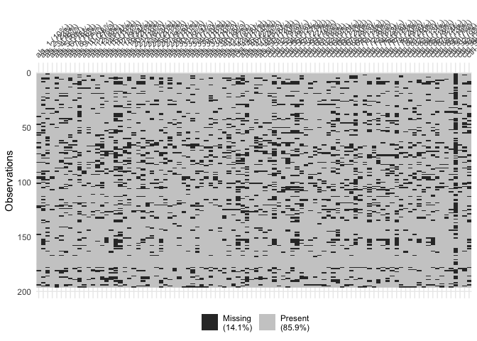

```r
      ggsave("plots/missing_vis_miss_heatmap_before.pdf", width = 11, height = 8, units = "in")
      se_abu_data_filtered =  filter_proteins(se_abu_data, "fraction", min = 0.66)
      vis_miss(as.data.frame(assay(se_abu_data_filtered)),show_perc = TRUE, show_perc_col = TRUE, cluster = F)
```

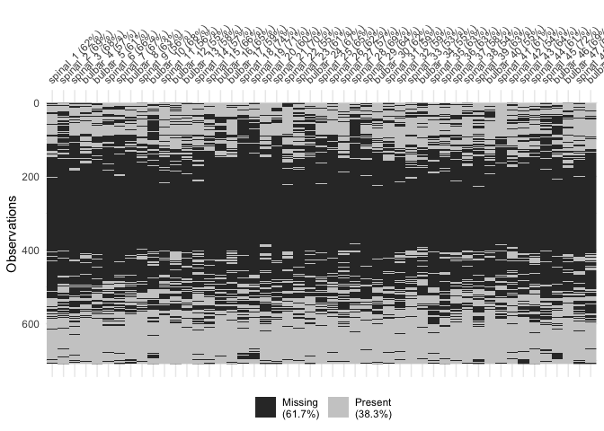

```r
      ggsave("plots/missing_vis_miss_heatmap_after.pdf", width = 11, height = 8, units = "in")

      #only ALS patients
      vis_miss(as.data.frame(assay(se_abu_data_ALS)),show_perc = TRUE, show_perc_col = TRUE, cluster = T)
```

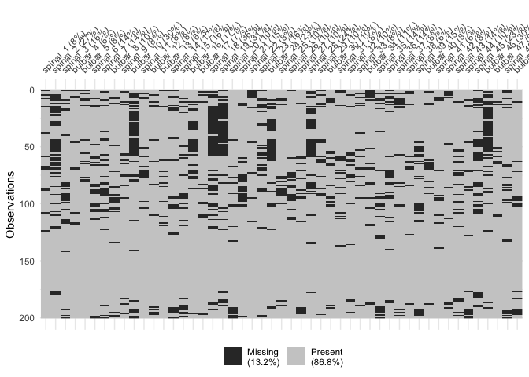

```r
      ggsave("plots/missing_vis_miss_heatmap_before_ALS.pdf", width = 11, height = 8, units = "in")
      #filter values that are missing more than 20% in at least one condition
      se_abu_data_filtered_ALS =  filter_proteins(se_abu_data_ALS, "fraction", min = 0.66)
      vis_miss(as.data.frame(assay(se_abu_data_filtered_ALS)),show_perc = TRUE, show_perc_col = TRUE, cluster = T)
```

```r
      ggsave("plots/missing_vis_miss_heatmap_after_ALS.pdf", width = 11, height = 8, units = "in")

      #dimensions of the data
      dim(se_abu_data)
```

```
## [1] 709  96
```

```r
      dim(se_abu_data_filtered)
```

```
## [1] 196  96
```

```r
      dim(se_abu_data_ALS)
```

```
## [1] 709  49
```

```r
      dim(se_abu_data_filtered_ALS)
```

```
## [1] 200  49
```

```r
      table(se_abu_data$sex)
```

```
##
## Female   Male
##     32     64
```

```r
      table(se_abu_data_ALS$sex)
```

```
##
## Female   Male
##     15     34
```

```r
      # % missing per patient:
      round(apply(X = as.data.frame(assay(se_abu_data)), function(x) sum(is.na(x)), MARGIN = 2) / nrow(as.data.frame(assay(se_abu_data))) * 100 , 1)
```

```
##   als_1   als_2   als_3   als_4   als_5   als_6   als_7   als_8   als_9  als_10
##    61.9    69.3    68.0    57.1    61.1    65.6    66.7    62.8    56.3    67.7
##  als_11  als_12  als_13  als_14  als_15  als_16  als_17  als_18  als_19  als_20
##    56.3    55.1    57.5    57.3    65.9    64.9    58.7    73.9    70.8    59.5
##  als_21  als_22  als_23  als_24  als_25  als_26  als_27  als_28  als_29  als_30
##    69.5    55.0    61.2    67.0    64.9    62.5    56.7    68.7    64.5    62.5
##  als_31  als_32  als_33  als_34  als_35  als_36  als_37  als_38  als_39  als_40
##    59.1    59.2    52.9    54.9    63.3    63.2    57.8    53.6    62.9    55.4
##  als_41  als_42  als_43  als_44 ctrl_45  als_46  als_47  als_48  als_49  als_50
##    60.9    53.6    63.9    60.6    70.9    71.8    68.5    52.3    60.2    60.9
## ctrl_51 ctrl_52 ctrl_53 ctrl_54 ctrl_55 ctrl_56 ctrl_57 ctrl_58 ctrl_59 ctrl_60
##    59.0    59.1    70.8    64.2    61.5    66.1    66.0    69.5    68.3    60.1
## ctrl_61 ctrl_62 ctrl_63 ctrl_64 ctrl_65 ctrl_66 ctrl_67 ctrl_68 ctrl_69 ctrl_70
##    57.1    59.4    60.5    59.7    62.6    68.0    68.4    58.7    61.4    61.1
## ctrl_71 ctrl_72 ctrl_73 ctrl_74 ctrl_75 ctrl_76 ctrl_77 ctrl_78 ctrl_79 ctrl_80
##    73.3    55.1    60.9    68.1    54.7    68.8    60.1    61.8    57.3    66.9
## ctrl_81 ctrl_82 ctrl_83 ctrl_84 ctrl_85 ctrl_86 ctrl_87 ctrl_88 ctrl_89 ctrl_90
##    55.4    57.3    61.2    58.4    64.2    56.0    56.8    59.9    63.2    58.3
## ctrl_91 ctrl_92 ctrl_93 ctrl_94 ctrl_95 ctrl_96
##    57.8    59.2    84.8    56.3    63.5    63.9
```

```r
      round(apply(X = as.data.frame(assay(se_abu_data_filtered)), function(x) sum(is.na(x)), MARGIN = 2) / nrow(as.data.frame(assay(se_abu_data))) * 100 , 1)
```

```
##   als_1   als_2   als_3   als_4   als_5   als_6   als_7   als_8   als_9  als_10
##     2.7     6.3     5.1     1.3     2.5     4.2     4.5     3.5     1.8     7.6
##  als_11  als_12  als_13  als_14  als_15  als_16  als_17  als_18  als_19  als_20
##     1.8     2.3     2.3     3.8     5.2     3.5     2.4     9.4     7.2     3.7
##  als_21  als_22  als_23  als_24  als_25  als_26  als_27  als_28  als_29  als_30
##     5.2     1.6     3.5     5.6     3.1     3.4     2.5     5.4     2.7     3.1
##  als_31  als_32  als_33  als_34  als_35  als_36  als_37  als_38  als_39  als_40
##     2.4     3.0     2.0     2.8     4.4     3.7     2.7     1.8     4.1     2.4
##  als_41  als_42  als_43  als_44 ctrl_45  als_46  als_47  als_48  als_49  als_50
##     2.0     2.3     4.5     3.0     6.6     5.8     7.2     1.3     4.5     3.7
## ctrl_51 ctrl_52 ctrl_53 ctrl_54 ctrl_55 ctrl_56 ctrl_57 ctrl_58 ctrl_59 ctrl_60
##     2.8     2.5     8.7     2.4     3.4     4.7     5.9     7.3     4.5     2.3
## ctrl_61 ctrl_62 ctrl_63 ctrl_64 ctrl_65 ctrl_66 ctrl_67 ctrl_68 ctrl_69 ctrl_70
##     2.3     2.3     2.4     2.8     3.1     5.6     5.5     2.4     3.5     3.9
## ctrl_71 ctrl_72 ctrl_73 ctrl_74 ctrl_75 ctrl_76 ctrl_77 ctrl_78 ctrl_79 ctrl_80
##     8.2     2.5     2.1     6.3     2.1     5.2     3.1     5.6     2.4     7.2
## ctrl_81 ctrl_82 ctrl_83 ctrl_84 ctrl_85 ctrl_86 ctrl_87 ctrl_88 ctrl_89 ctrl_90
##     2.8     1.8     3.5     3.1     4.4     2.4     3.8     3.5     4.1     2.0
## ctrl_91 ctrl_92 ctrl_93 ctrl_94 ctrl_95 ctrl_96
##     2.0     2.5    16.2     1.1     3.9     6.5
```

```r
      #variance for males and females
      female = summary(rowVars(assay(se_abu_data_filtered[, se_abu_data_filtered$sex == "Female"])))
      male = summary(rowVars(assay(se_abu_data_filtered[, se_abu_data_filtered$sex == "Male"])))
      cbind(female,male)
```

```
##              female        male
## Min.      0.2899993   0.5281241
## 1st Qu.   0.7026452   1.0030690
## Median    1.1823850   1.5080187
## Mean      2.1006877   2.1734328
## 3rd Qu.   1.8641093   2.7057090
## Max.     10.1300093   7.9022284
## NA's    155.0000000 178.0000000
```

## Imputation and normalization

```r
set.seed(9)

#all patients
norm <- normalize_vsn(se_abu_data_filtered)

#only ALS
norm_ALS <- normalize_vsn(se_abu_data_filtered_ALS)

#all patients
norm_imp_MinProb <- impute(norm, fun = "MinProb", q=0.01)
```

```
## [1] 0.9616073
```

```r
#only ALS
norm_imp_MinProb_ALS <- impute(norm_ALS, fun = "MinProb", q=0.01)
```

```
## [1] 0.9199105
```

```r
#all patients
norm_imp_knn <- impute(norm, fun = "knn")

#only ALS
norm_imp_knn_ALS <- impute(norm_ALS, fun = "knn")

data = list(imp_MinProb = norm_imp_MinProb,
            imp_knn = norm_imp_knn,
            imp_MinProb_ALS = norm_imp_MinProb_ALS,
            imp_knn_ALS = norm_imp_knn_ALS
            )
saveRDS(data, file = "results/summarized_experiments_imputed.rds")
```

## Differential expression analysis (DEx)

```r
covariates = c("no_cov", "age_cov", "sex_cov", "age_sex_cov")
covariates_f = c(~0 + condition,
                 ~0 + condition + age_cat,
                 ~0 + condition + sex,
                 ~0 + condition + age_cat + sex)
patients = c("all_patients", "only_female", "only_male")
patients_f = c(NA, "Female", "Male")
res = list()

l = 1
for(k in 1:length(data)){
  for(i in 1:length(covariates)){
    for(j in 1:length(patients)){

       title = paste0(names(data)[k],"_",covariates[i], "_", patients[j])
        d = data[[k]]
        if(j >1) { d = d[,d$sex == patients_f[j]] }
        control = "ctrl"
        if(grepl("ALS", title)){control = "bulbar"}
        if(i < 3 | j == 1){
          print(title)
          print(dim(d))
          t = test_diff(d, type = "control", control = control,
            test = NULL, design_formula = formula(covariates_f[[i]]))
          res[[l]] = as.data.frame(t@elementMetadata@listData)
          res[[l]]$fdr = p.adjust(res[[l]][,grep("p.val",colnames(res[[l]]))], method="BH")
          print(dim(res[[l]]))
          names(res)[l] = title
          write.csv(res[[l]], file = paste0("results/DEx", title, ".csv"))
          l = l+1

        }}}}
```

```
## [1] "imp_MinProb_no_cov_all_patients"
## [1] 196  96
```

```
## Tested contrasts: als_vs_ctrl
```

```
## [1] 196  16
## [1] "imp_MinProb_no_cov_only_female"
## [1] 196  32
```

```
## Tested contrasts: als_vs_ctrl
```

```
## [1] 196  16
## [1] "imp_MinProb_no_cov_only_male"
## [1] 196  64
```

```
## Tested contrasts: als_vs_ctrl
```

```
## [1] 196  16
## [1] "imp_MinProb_age_cov_all_patients"
## [1] 196  96
```

```
## Tested contrasts: als_vs_ctrl
```

```
## [1] 196  16
## [1] "imp_MinProb_age_cov_only_female"
## [1] 196  32
```

```
## Tested contrasts: als_vs_ctrl
```

```
## [1] 196  16
## [1] "imp_MinProb_age_cov_only_male"
## [1] 196  64
```

```
## Tested contrasts: als_vs_ctrl
```

```
## [1] 196  16
## [1] "imp_MinProb_sex_cov_all_patients"
## [1] 196  96
```

```
## Tested contrasts: als_vs_ctrl
```

```
## [1] 196  16
## [1] "imp_MinProb_age_sex_cov_all_patients"
## [1] 196  96
```

```
## Tested contrasts: als_vs_ctrl
```

```
## [1] 196  16
## [1] "imp_knn_no_cov_all_patients"
## [1] 196  96
```

```
## Tested contrasts: als_vs_ctrl
```

```
## [1] 196  16
## [1] "imp_knn_no_cov_only_female"
## [1] 196  32
```

```
## Tested contrasts: als_vs_ctrl
```

```
## [1] 196  16
## [1] "imp_knn_no_cov_only_male"
## [1] 196  64
```

```
## Tested contrasts: als_vs_ctrl
```

```
## [1] 196  16
## [1] "imp_knn_age_cov_all_patients"
## [1] 196  96
```

```
## Tested contrasts: als_vs_ctrl
```

```
## [1] 196  16
## [1] "imp_knn_age_cov_only_female"
## [1] 196  32
```

```
## Tested contrasts: als_vs_ctrl
```

```
## [1] 196  16
## [1] "imp_knn_age_cov_only_male"
## [1] 196  64
```

```
## Tested contrasts: als_vs_ctrl
```

```
## [1] 196  16
## [1] "imp_knn_sex_cov_all_patients"
## [1] 196  96
```

```
## Tested contrasts: als_vs_ctrl
```

```
## [1] 196  16
## [1] "imp_knn_age_sex_cov_all_patients"
## [1] 196  96
```

```
## Tested contrasts: als_vs_ctrl
```

```
## [1] 196  16
## [1] "imp_MinProb_ALS_no_cov_all_patients"
## [1] 200  49
```

```
## Tested contrasts: spinal_vs_bulbar
```

```
## [1] 200  62
## [1] "imp_MinProb_ALS_no_cov_only_female"
## [1] 200  15
```

```
## Tested contrasts: spinal_vs_bulbar
```

```
## [1] 200  62
## [1] "imp_MinProb_ALS_no_cov_only_male"
## [1] 200  34
```

```
## Tested contrasts: spinal_vs_bulbar
```

```
## [1] 200  62
## [1] "imp_MinProb_ALS_age_cov_all_patients"
## [1] 200  49
```

```
## Tested contrasts: spinal_vs_bulbar
```

```
## [1] 200  62
## [1] "imp_MinProb_ALS_age_cov_only_female"
## [1] 200  15
```

```
## Tested contrasts: spinal_vs_bulbar
```

```
## [1] 200  62
## [1] "imp_MinProb_ALS_age_cov_only_male"
## [1] 200  34
```

```
## Tested contrasts: spinal_vs_bulbar
```

```
## [1] 200  62
## [1] "imp_MinProb_ALS_sex_cov_all_patients"
## [1] 200  49
```

```
## Tested contrasts: spinal_vs_bulbar
```

```
## [1] 200  62
## [1] "imp_MinProb_ALS_age_sex_cov_all_patients"
## [1] 200  49
```

```
## Tested contrasts: spinal_vs_bulbar
```

```
## [1] 200  62
## [1] "imp_knn_ALS_no_cov_all_patients"
## [1] 200  49
```

```
## Tested contrasts: spinal_vs_bulbar
```

```
## [1] 200  62
## [1] "imp_knn_ALS_no_cov_only_female"
## [1] 200  15
```

```
## Tested contrasts: spinal_vs_bulbar
```

```
## [1] 200  62
## [1] "imp_knn_ALS_no_cov_only_male"
## [1] 200  34
```

```
## Tested contrasts: spinal_vs_bulbar
```

```
## [1] 200  62
## [1] "imp_knn_ALS_age_cov_all_patients"
## [1] 200  49
```

```
## Tested contrasts: spinal_vs_bulbar
```

```
## [1] 200  62
## [1] "imp_knn_ALS_age_cov_only_female"
## [1] 200  15
```

```
## Tested contrasts: spinal_vs_bulbar
```

```
## [1] 200  62
## [1] "imp_knn_ALS_age_cov_only_male"
## [1] 200  34
```

```
## Tested contrasts: spinal_vs_bulbar
```

```
## [1] 200  62
## [1] "imp_knn_ALS_sex_cov_all_patients"
## [1] 200  49
```

```
## Tested contrasts: spinal_vs_bulbar
```

```
## [1] 200  62
## [1] "imp_knn_ALS_age_sex_cov_all_patients"
## [1] 200  49
```

```
## Tested contrasts: spinal_vs_bulbar
```

```
## [1] 200  62
```

```r
saveRDS(res, file = "results/DEx_results_all_in_list.rds")
```

## Visualization 1: mean expressions boxplots

```r
#visualize every dataset, also raw
data_all = list(raw = se_abu_data, filtered = se_abu_data_filtered, normalized = norm,
                raw_ALS = se_abu_data_ALS, filtered_ALS = se_abu_data_filtered_ALS, normalized_ALS = norm_ALS)
data_all = c(data_all, data)

mean_expression_plot = function(data, file_sample, file_mass){
  ggplot(data = reshape2::melt(data), aes(x=Var1, y=value)) +
  geom_boxplot(color="darkseagreen4", fill="darkseagreen3") +
  theme_set(theme_minimal()) +
  theme_few() +
  scale_colour_few() +
  theme(legend.position = "none") +
  theme(axis.text.x = element_text(angle = 90, vjust = 0.5, hjust=1)) +
  theme(axis.text=element_text(size=6))

ggsave(file_sample, width = 11, height = 8, units = "in")

ggplot(data = reshape2::melt(data), aes(x=reorder(as.factor(Var2),value), y=value)) +
  geom_boxplot(color="darkseagreen4", fill="darkseagreen3") +
  theme_set(theme_minimal()) +
  theme_few() +
  scale_colour_few() +
  theme(legend.position = "none") +
  theme(axis.text.x = element_text(angle = 90, vjust = 0.5, hjust=1)) +
  theme(axis.text=element_text(size=6))

ggsave(file_mass, width = 11*2, height = 8, units = "in")
}

for(i in 1:length(data_all)){
  mean_expression_plot(data = t(assay(data_all[[i]])),
                      file_sample = paste0("plots/boxplots_expression_each_sample_",
                                            names(data_all)[i],
                                            ".pdf"),
                      file_mass = paste0("plots/boxplots_expression_each_protein_",
                                            names(data_all)[i],
                                            ".pdf"))
}
```

## Visualization 1b: Density plot

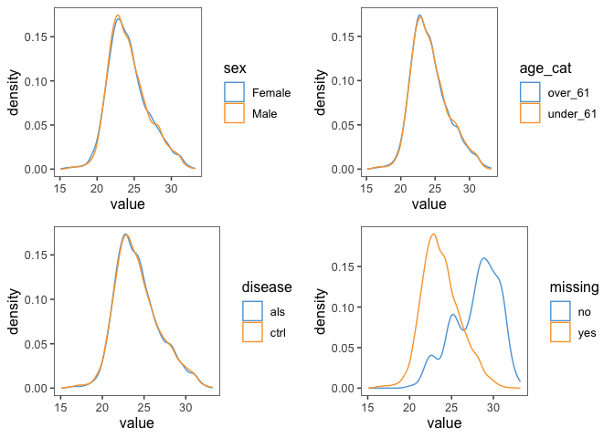

```r
#density plots of clinical variables
d = as.data.frame(cbind(clin[,c("sex", "age_cat", "disease")], as.data.frame(t(assay(data_all[["normalized"]])))))
long <- melt(setDT(d), id.vars = c("sex", "age_cat", "disease"), variable.name = "protein")

#density plots for variables with and without missing
d = as.data.frame(assay(data_all[["normalized"]]))
missing = apply(d, function(x) sum(is.na(x)) , MARGIN = 1)
missing[missing>0] = "yes"
missing[missing == 0] = "no"
missing = as.factor(missing)
d2 = cbind(missing,d)
long2 <- melt(setDT(d2), id.vars = "missing", variable.name = "protein")

a = ggplot(long, aes(x=value, color=sex)) +
  geom_density() +
  theme_few() +
  scale_colour_few()
b = ggplot(long, aes(x=value, color=age_cat)) +
  geom_density() +
  theme_few() +
  scale_colour_few()
c = ggplot(long, aes(x=value, color=disease)) +
  geom_density() +
  theme_few() +
  scale_colour_few()
d = ggplot(long2, aes(x=value, color=missing)) +
  geom_density() +
  theme_few() +
  scale_colour_few()

library(ggpubr)
ggarrange(a,b,c,d, ncol = 2, nrow = 2)
```

```r
ggsave(file = "plots/density.pdf", width = 11, height = 8, units = "in")
```

## Visualization 2: heatmaps

The visualizations with the heatmaps, especially the ones with column-wise clustering, show a very clear batch effect in the data. This batch effect remains if we use different imputation methods.

```
## [1] "imp_MinProb_ward.D"
```

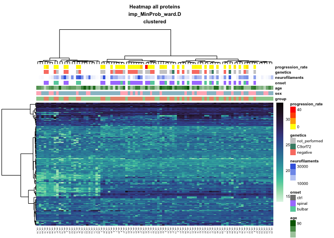

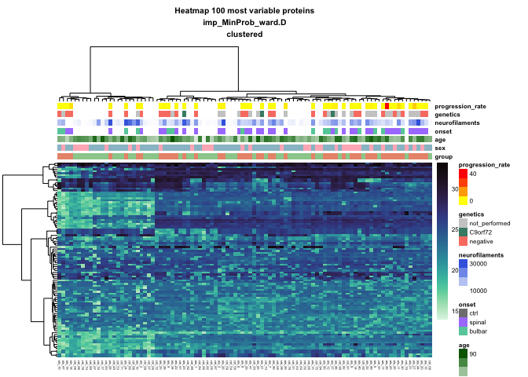

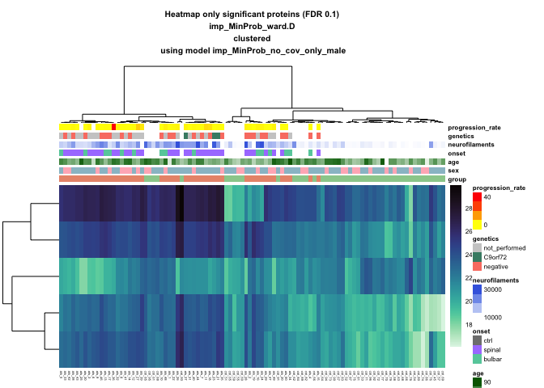

```
## [1] "imp_knn_ward.D"
```

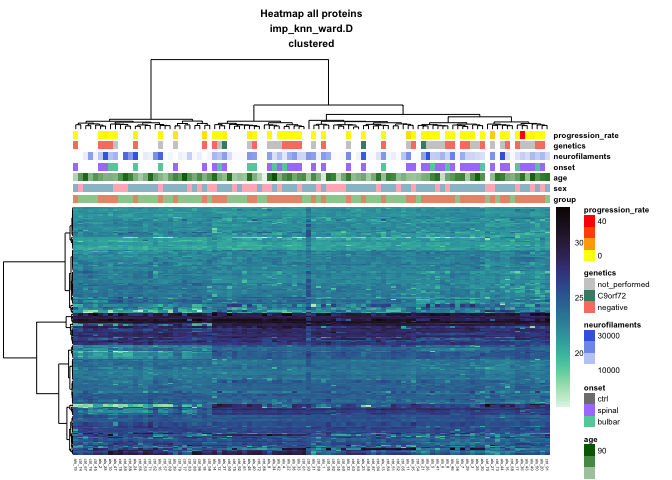

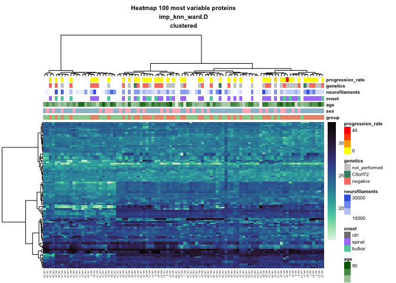

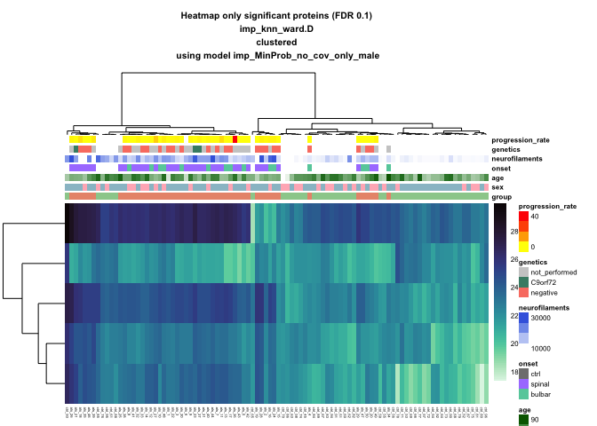

```
## [1] "imp_MinProb_ALS_ward.D"
```

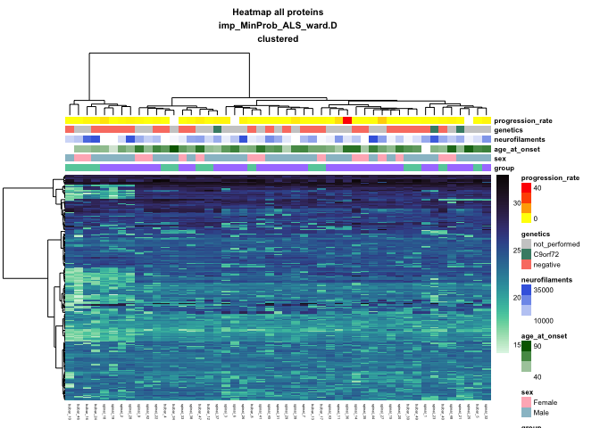

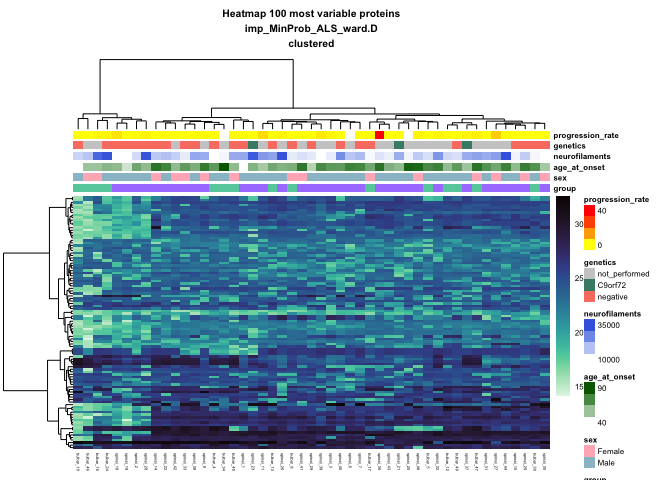

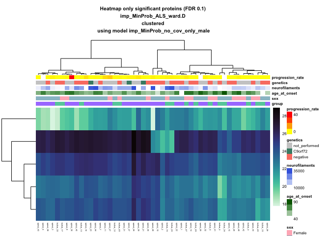

```
## [1] "imp_knn_ALS_ward.D"
```

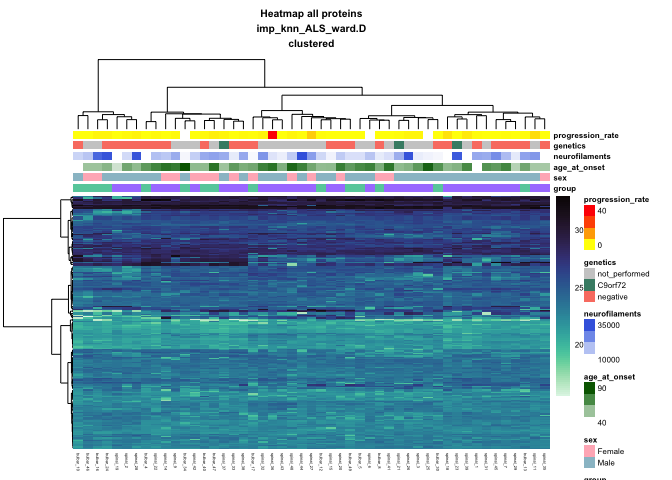

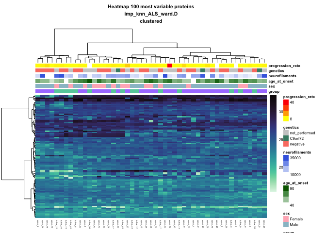

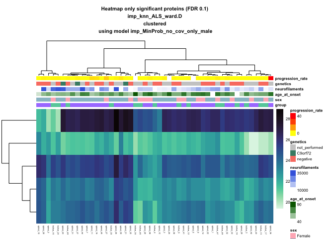

```r
library(readr)
set.seed(9)
#functions for saving the heatmaps as figures

        save_pheatmap_pdf <- function(x, filename, width=11/2, height=8/2) {
           stopifnot(!missing(x))
           stopifnot(!missing(filename))
           pdf(filename, width=width, height=height)
           grid::grid.newpage()
           grid::grid.draw(x$gtable)
           dev.off()
        }

        make_pheatmap <- function(data, cluster_cols = T, main = "Heatmap", clustering_method = "ward.D"){
          p = pheatmap::pheatmap(data, name = "expression", cutree_cols = 1,
                  show_colnames = T,
                  show_rownames = FALSE,
                  fontsize = 6,
                  fontsize_col = 3,
                  annotation_col = annotation,
                  annotation_colors = annotation_colours,
                  color = viridis::viridis(100, option="G", direction = -1,),
                  main = main,
                  border_color=NA,
                  cluster_cols = cluster_cols,
                  clustering_method = clustering_method,
                  na_col = "grey50")
          return(p)
        }

# all clustering methods:
        method = "ward.D"

# loop for all datasets and all methods
        for(i in 1:length(data)){
          for(j in 1:length(method)){
        title = paste0(names(data)[i], "_", method[j])
        print(title)

        # get annotations and dataframe ready
        #annotations
        if(!grepl("ALS", title)){
        annotation = data.frame(group = as.factor(data[[i]]$condition),
                                sex = as.factor(data[[i]]$sex),
                                age = data[[i]]$age,
                                onset = as.factor(data[[i]]$onset),
                                neurofilaments = data[[i]]$neurofilaments,
                                genetics = data[[i]]$genetics,
                                progression_rate = data[[i]]$progression_rate)
        rownames(annotation) = data[[i]]@colData$ID
        annotation_colours <- list(
          group = c(ctrl = "darkseagreen3", als = "darksalmon"),
          sex = c(Female = "lightpink", Male ="lightblue3"),
          age = c("white", "darkgreen"),
          onset = c(ctrl = "grey50", spinal = "mediumpurple1", bulbar = "mediumaquamarine"),
          neurofilaments = c("white", "royalblue"),
          genetics = c(not_performed = "grey80", C9orf72 = "aquamarine4", negative = "salmon"),
          progression_rate = c("yellow", "red"))
        }
                if(grepl("ALS", title)){
        annotation = data.frame(group = as.factor(data[[i]]$condition),
                                sex = as.factor(data[[i]]$sex),
                                age_at_onset = data[[i]]$age_at_onset,
                                neurofilaments = data[[i]]$neurofilaments,
                                genetics = data[[i]]$genetics,
                                progression_rate = data[[i]]$progression_rate)
        rownames(annotation) = data[[i]]@colData$ID
        annotation_colours <- list(
          group = c(spinal = "mediumpurple1", bulbar = "mediumaquamarine"),
          sex = c(Female = "lightpink", Male ="lightblue3"),
          age_at_onset = c("white", "darkgreen"),
          neurofilaments = c("white", "royalblue"),
          genetics = c(not_performed = "grey80", C9orf72 = "aquamarine4", negative = "salmon"),
          progression_rate = c("yellow", "red"))
        }

#create heatmaps with all patients

        #without grouping, all proteins
        p = make_pheatmap(data = assay(data[[i]]), cluster_cols = T, main = paste0("Heatmap all proteins\n",title, "\nclustered"), clustering_method = method[j])
        save_pheatmap_pdf(p, filename = paste0("plots/heatmap_clustered_",title,".pdf"))

        # without grouping, 100 most variable proteins
        d = assay(data[[i]])
        d2 = head(order(rowVars(d),decreasing = T),100)
        p = make_pheatmap(data = d[d2,], cluster_cols = T, main = paste0("Heatmap 100 most variable proteins\n",title, "\nclustered"), clustering_method = method[j])
        save_pheatmap_pdf(p, filename = paste0("plots/heatmap_clustered_mostvar_",title,".pdf"))
        save_pheatmap_pdf(p, filename = paste0("plots/heatmap_clustered_mostvar_",title,"_big.pdf"), width=11, height=8)

        #heatmap with only significant genes
        r = res[["imp_MinProb_no_cov_only_male"]]
        sig_met = r$name[r$fdr<0.1]
            if(length(sig_met)>2){
              d = d[sig_met,]
              p = make_pheatmap(data = d, cluster_cols = T, main = paste0("Heatmap only significant proteins (FDR 0.1)\n",title, "\nclustered","\n using model imp_MinProb_no_cov_only_male" ), clustering_method = method[j])
              save_pheatmap_pdf(p, paste0("plots/heatmap_clustered_only_significant_",title,".pdf"))
            }}}
```

```r
#collect clustering labels ALS patients MinProb imputation Ward.D2 clustering
        set.seed(9)
        i = "imp_MinProb_ALS"
        title = paste0(i, "_", method[j])
        # without grouping, 100 most variable proteins
        (d = assay(data[[i]]))
```

[output not shown]

[output cut: 1553 more lines]

```
## SUSD5_p105       24.84493  22.03228  22.40298  24.79325  26.28774  24.70110
## SUSD5_p227       20.86248  19.37684  16.66556  21.41237  22.76300  22.15868
## SUSD5_p240       22.41645  21.73359  16.99578  17.91837  22.79775  22.79519
## SUSD5_p241       22.41645  21.73359  15.99357  19.63757  22.79775  22.79519
## SUSD5_p325       22.90840  22.51229  22.30685  22.53999  23.65545  22.87219
## SYT11_p140       22.64954  22.54912  22.99001  23.31472  24.04281  22.85937
## TF_p389          22.68798  22.96137  15.78068  21.90002  21.85717  19.38686
## TGOLN2_p296      23.02905  17.57578  16.42444  17.79098  24.23939  19.42219
## TGOLN2_p298      23.02905  20.13541  23.51021  19.09331  24.23939  23.72775
## TGOLN2_p70       25.60250  25.10169  16.14132  24.94645  24.56315  25.30378
## TGOLN2_p71       25.60250  25.10169  16.04908  24.94645  24.56315  25.30378
## TMEM132A_p529    22.58161  19.77642  23.20894  23.02552  23.96701  23.96918
## TMSB4X_p23       20.68128  25.00896  23.93457  24.43752  24.42272  24.10583
## VCAN_p2116       20.37087  18.00218  23.09880  24.61582  23.38611  22.86299
## VTN_p312         26.49694  29.42961  23.97639  20.89974  21.12961  22.97351
```

```r
        d2 = head(order(rowVars(d),decreasing = T),100)
```

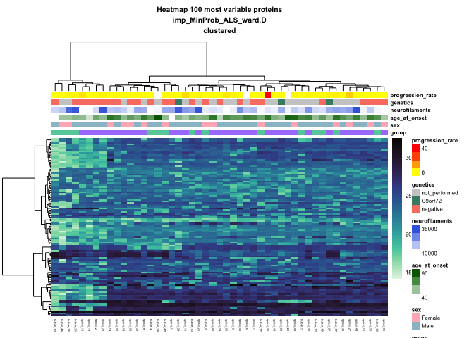

```r
        p = make_pheatmap(data = d[d2,], cluster_cols = T, main = paste0("Heatmap 100 most variable proteins\n",title, "\nclustered"), clustering_method = method[j])
```

```r
        cluster_labels = as.data.frame(sort(cutree(p$tree_col, k=2)))
        colnames(cluster_labels) = "cluster"
        patids = as.data.frame(data[[i]]@colData[,c("ID", "label")])

        cluster_labels  = merge(cluster_labels, patids, by = "row.names", all = TRUE)
        write_csv(cluster_labels, file="results/cluster_labels_heatmap_MinProb_ALS_Ward.D2.csv")
        saveRDS(data[[i]], file = "results/summarized_experiment_for_clustering_imp_MinProb_ALS_ward.D2.rds")
```

## Visualization 3: UMAP plots

```r
# set seed for reproducible results
set.seed(9)

          group = c("darksalmon","darkseagreen3")
          sex = c("lightpink", "lightblue3")
          onset = c("mediumaquamarine", "mediumpurple1","grey80")
          onset_ALS = c("mediumaquamarine", "mediumpurple1")
          age_cat = c("darkgreen", "lightgreen")
          center = c("blue3", "yellow4")


#THE FUNCTION

UMAP_density_plot = function(data,
                             ggtitle = "UMAP with disease status labels",
                             legend_name = "Disease status",
                             labels = clin$Condition,
                             colour_set = c("seagreen4", "slateblue1", "salmon"),
                             shape = rep(16, nrow(umap_plot)),
                             shapeTF = F){
      # run umap function
      umap_out = umap::umap(data)
      umap_plot = as.data.frame(umap_out$layout)

      #add condition labels
      umap_plot$group = labels

      # plot umap
      p1 = ggplot(umap_plot) + geom_point(aes(x=V1, y=V2, color = as.factor(group),), shape=shape) +
        ggtitle(ggtitle) +
          theme_few() +
          scale_colour_few() +
          scale_color_manual(name = legend_name,
                           labels = levels(as.factor(umap_plot$group)),
                           values = colour_set) +
          scale_fill_manual(values=colour_set)

      #add shape argument if we want to change shapes
      if(shapeTF){
        p1 = p1 + scale_shape_manual(name = "Sex",
                    labels = levels(as.factor(shape)),
                    values=c(15, 17))
      }

      xdens <-
        axis_canvas(p1, axis = "x") +
        geom_density(data = umap_plot, aes(x = V1, fill = group, colour = group), alpha = 0.3) +
        scale_fill_manual( values = colour_set) +
        scale_colour_manual( values = colour_set)
      ydens <-
        axis_canvas(p1, axis = "y", coord_flip = TRUE) +
        geom_density(data = umap_plot, aes(x = V2, fill = group, colour = group), alpha = 0.3) +
        coord_flip() +
        scale_fill_manual(values = colour_set) +
        scale_colour_manual( values = colour_set)
      p1 %>%
        insert_xaxis_grob(xdens, grid::unit(1, "in"), position = "top") %>%
        insert_yaxis_grob(ydens, grid::unit(1, "in"), position = "right") %>%
        ggdraw()

      p1
      p1_label = p1 + geom_text(label = rownames(umap_plot), x = umap_plot$V1, y = umap_plot$V2,
                     hjust = 0, nudge_x = 1, size = 1.5, colour = "grey")
      return(list(plot_simple = p1, plot_with_labels = p1_label))
}

plots = list()
plots_with_labels = list()
l = 1

for(i in 1:length(data)){
  title = names(data)[i]
  d = t(assay(data[[i]]))
  labels_disease = data[[i]]$condition
  if(!grepl("ALS", title)){labels_onset = data[[i]]$onset} #only run this one when we have case & control
  labels_sex = data[[i]]$sex
  labels_age = data[[i]]$age_cat
  labels_center = data[[i]]$center
  if(grepl("ALS", title)){group = onset_ALS} #change the colour labels when switching from case & control to only ALS

#perform plots with function
        umap = UMAP_density_plot(data = d,
                          ggtitle = paste0("UMAP with disease status labels\n", title),
                          legend_name = "Disease status",
                          labels = labels_disease,
                          colour_set = group)
        plots[[l]] = umap$plot_simple
        plots_with_labels[[l]] =  umap$plot_with_labels
        names(plots)[l] = names(plots_with_labels)[l] = paste0(title, "_disease")
        l = l+1


        #disease color AND sex label
        umap =  UMAP_density_plot(data = d,
                          ggtitle = paste0("UMAP with disease status labels & sex shape\n", title),
                          legend_name = "Disease status",
                          labels = labels_disease,
                          colour_set = group,
                          shape = labels_sex,
                          shapeTF = T)
        plots[[l]] = umap$plot_simple
        plots_with_labels[[l]] =  umap$plot_with_labels
        names(plots)[l] = names(plots_with_labels)[l] = paste0(title, "_disease_and_sex")
        l = l+1

        umap = UMAP_density_plot(data = d,
                          ggtitle = paste0("UMAP with center labels\n", title),
                          legend_name = "Center",
                          labels = labels_center,
                          colour_set = center)
        plots[[l]] = umap$plot_simple
        plots_with_labels[[l]] =  umap$plot_with_labels
        names(plots)[l] = names(plots_with_labels)[l] = paste0(title, "_center")
        l = l+1

        if(!grepl("ALS", title)){ #only run this one when we have case & control
          umap = UMAP_density_plot(data = d,
                          ggtitle = paste0("UMAP with onset status labels\n", title),
                          legend_name = "Onset labels",
                          labels = labels_onset,
                          colour_set = onset)
          plots[[l]] = umap$plot_simple
          plots_with_labels[[l]] =  umap$plot_with_labels
          names(plots)[l] = names(plots_with_labels)[l] = paste0(title, "_onset")
          l = l+1
        }

        umap = UMAP_density_plot(data = d,
                          ggtitle = paste0("UMAP with sex labels\n", title),
                          legend_name = "Sex label",
                          labels = labels_sex,
                          colour_set = sex)
        plots[[l]] = umap$plot_simple
        plots_with_labels[[l]] =  umap$plot_with_labels
        names(plots)[l] = names(plots_with_labels)[l] = paste0(title, "_sex")
        l = l+1

        umap = UMAP_density_plot(data = d,
                          ggtitle = paste0("UMAP with age labels\n", title),
                          legend_name = "Age label",
                          labels = labels_age,
                          colour_set = age_cat)
        plots[[l]] = umap$plot_simple
        plots_with_labels[[l]] =  umap$plot_with_labels
        names(plots)[l] = names(plots_with_labels)[l] = paste0(title, "_age")
        l = l+1

#perform plots with only most variable proteins
        d2 = head(order(colVars(d),decreasing = T),100)
        title = paste0("mostvar_",title)

        umap = UMAP_density_plot(data = d[,d2],
                          ggtitle = paste0("UMAP with disease status labels\n", title, "\nwith 100 most variable proteins"),
                          legend_name = "Disease status",
                          labels = labels_disease,
                          colour_set = group)
        plots[[l]] = umap$plot_simple
        plots_with_labels[[l]] =  umap$plot_with_labels
        names(plots)[l] = names(plots_with_labels)[l] = paste0(title, "_disease")
        l = l+1

          #disease color AND sex label
         umap = UMAP_density_plot(data = d[,d2],
                          ggtitle = paste0("UMAP with disease status labels & sex shape\n", title, "\nwith 100 most variable proteins"),
                          legend_name = "Disease status",
                          labels = labels_disease,
                          colour_set = group,
                          shape = labels_sex,
                          shapeTF = T)
        plots[[l]] = umap$plot_simple
        plots_with_labels[[l]] =  umap$plot_with_labels
        names(plots)[l] = names(plots_with_labels)[l] = paste0(title, "_disease_and_sex")
        l = l+1

        if(!grepl("ALS", title)){ #only run this one when we have case & control
          umap = UMAP_density_plot(data = d[,d2],
                            ggtitle = paste0("UMAP with onset status labels\n", title, "\nwith 100 most variable proteins"),
                            legend_name = "Onset labels",
                            labels = labels_onset,
                            colour_set = onset)
            plots[[l]] = umap$plot_simple
            plots_with_labels[[l]] =  umap$plot_with_labels
            names(plots)[l] = names(plots_with_labels)[l] = paste0(title, "_onset")
            l = l+1}

        umap = UMAP_density_plot(data = d[,d2],
                          ggtitle = paste0("UMAP with sex labels\n", title, "\nwith 100 most variable proteins"),
                          legend_name = "Sex label",
                          labels = labels_sex,
                          colour_set = sex)
        plots[[l]] = umap$plot_simple
        plots_with_labels[[l]] =  umap$plot_with_labels
        names(plots)[l] = names(plots_with_labels)[l] = paste0(title, "_sex")
        l = l+1

        umap = UMAP_density_plot(data = d[,d2],
                          ggtitle = paste0("UMAP with age labels\n", title, "\nwith 100 most variable proteins"),
                          legend_name = "Age label",
                          labels = labels_age,
                          colour_set = age_cat)
        plots[[l]] = umap$plot_simple
        plots_with_labels[[l]] =  umap$plot_with_labels
        names(plots)[l] = names(plots_with_labels)[l] = paste0(title, "_age")
        l = l+1

        umap = UMAP_density_plot(data = d[,d2],
                          ggtitle = paste0("UMAP with center labels\n", title, "\nwith 100 most variable proteins"),
                          legend_name = "Center label",
                          labels = labels_center,
                          colour_set = center)
        plots[[l]] = umap$plot_simple
        plots_with_labels[[l]] =  umap$plot_with_labels
        names(plots)[l] = names(plots_with_labels)[l] = paste0(title, "_center")
        l = l+1
}
#plot the unlabeled
plots_MinProb = plots[grep("MinProb", names(plots))]
plots_MinProb_ALS = plots_MinProb[grep("ALS", names(plots_MinProb))]
plots_MinProb_all = plots_MinProb[-grep("ALS", names(plots_MinProb))]
plots_knn = plots[grep("knn", names(plots))]
plots_knn_ALS = plots_knn[grep("ALS", names(plots_knn))]
plots_knn_all = plots_knn[-grep("ALS", names(plots_knn))]

allplots <- ggarrange(plotlist=plots_MinProb_ALS,
                                  ncol = 5, nrow = 2)
ggsave("plots/UMAPs_MinProb_ALS.pdf", width = 5*5, height = 3*2, units = "in")
allplots <- ggarrange(plotlist=plots_MinProb_all,
                                  ncol = 6, nrow = 2)
ggsave("plots/UMAPs_MinProb_all.pdf", width = 5*6, height = 3*2, units = "in")
allplots <- ggarrange(plotlist=plots_knn_ALS,
                                  ncol = 5, nrow = 2)
ggsave("plots/UMAPs_knn_ALS.pdf", width = 5*5, height = 3*2, units = "in")
allplots <- ggarrange(plotlist=plots_knn_all,
                                  ncol = 6, nrow = 2)
ggsave("plots/UMAPs_knn_all.pdf", width = 5*6, height = 3*2, units = "in")

#plot the labeled
plots_MinProb = plots_with_labels[grep("MinProb", names(plots_with_labels))]
plots_MinProb_ALS = plots_MinProb[grep("ALS", names(plots_MinProb))]
plots_MinProb_all = plots_MinProb[-grep("ALS", names(plots_MinProb))]
plots_knn = plots_with_labels[grep("knn", names(plots_with_labels))]
plots_knn_ALS = plots_knn[grep("ALS", names(plots_knn))]
plots_knn_all = plots_knn[-grep("ALS", names(plots_knn))]

allplots <- ggarrange(plotlist=plots_MinProb_ALS,
                                  ncol = 5, nrow = 2)
ggsave("plots/UMAPs_MinProb_ALS_labeled.pdf", width = 5*5, height = 3*2, units = "in", limitsize = F)
allplots <- ggarrange(plotlist=plots_MinProb_all,
                                  ncol = 6, nrow = 2)
ggsave("plots/UMAPs_MinProb_all_labeled.pdf", width = 5*6, height = 3*2, units = "in", limitsize = F)
allplots <- ggarrange(plotlist=plots_knn_ALS,
                                  ncol = 5, nrow = 2)
ggsave("plots/UMAPs_knn_ALS_labeled.pdf", width = 5*5, height = 3*2, units = "in", limitsize = F)
allplots <- ggarrange(plotlist=plots_knn_all,
                                  ncol = 6, nrow = 2)
ggsave("plots/UMAPs_knn_all_labeled.pdf", width = 5*6, height = 3*2, units = "in", limitsize = F)
```

## Visualization 4: Volcano plots

```r
volcano_plot <- function(data_res, alpha_sig, name_title){
  logFC = data_res[,grep("diff",colnames(data_res))]
  fdr = data_res$fdr
  df <- data.frame(x = logFC,
                   y = -log10(fdr),
                   name = data_res$name)
  names(df) <- c("x","y","name")
  df <- df %>%
    mutate(omic_type = case_when(x >= 0 & y >= (-log10(alpha_sig)) ~ "up",
                                 x <= (0) & y >= (-log10(alpha_sig)) ~ "down",
                                 TRUE ~ "ns"))
  cols <- c("up" = "#d4552b", "down" = "#26b3ff", "ns" = "grey")
  sizes <- c("up" = 2, "down" = 2, "ns" = 1)
  alphas <- c("up" = 0.7, "down" = 0.7, "ns" = 0.5)
  ggplot(data = df, aes(x,y)) +
    geom_point(aes(colour = omic_type),
               alpha = 0.5,
               shape = 16,
               size = 3) +
    geom_hline(yintercept = -log10(alpha_sig),
               linetype = "dashed") +
    geom_vline(xintercept = 0,linetype = "dashed") +
    geom_point(data = filter(df, y >= (-log10(alpha_sig))),
               aes(colour = omic_type),
               alpha = 0.5,
               shape = 16,
               size = 4) +
    #annotate(geom="text", x=-1.9, y= (-log10(alpha_sig)) + 0.15, label="FDR = 10%",size = 5) +
    geom_text_repel(data = filter(df, y >= (-log10(alpha_sig)) & y > 0),
                     aes(label = name),
                     force = 1,
                    hjust = 1,
                     nudge_x = - 0.3,
                    nudge_y = 0.1,
                    #direction = "x",
                     max.overlaps = 5,
                    segment.size = 0.2,
                     size = 4) +
    geom_text_repel(data = filter(df, y >= (-log10(alpha_sig)) & y < 0),
                    aes(label = name),
                    force = 1,
                    hjust = 0,
                    nudge_x = 0.3,
                    nudge_y = 0.1,
                    #direction = "y",
                    max.overlaps = 5,
                    size = 4) +
    scale_colour_manual(values = cols) +
    scale_fill_manual(values = cols) +
    scale_x_continuous(expand = c(0, 0),
                       limits = c(-4, 4)) +
    scale_y_continuous(expand = c(0, 0), limits = c(-0.1, NA)) +
    labs(title = name_title,
         x = "log2(fold change)",
         y = expression(-log[10] ~ "(adjusted p-value)"),
         colour = "Differential \nExpression") +
    theme_classic() + # Select theme with a white background
    theme(axis.title.y = element_text(size = 14),
          axis.title.x = element_text(size = 14),
          axis.text = element_text(size = 12),
          plot.title = element_text(size = 15, hjust = 0.5),
          text = element_text(size = 14)) +
    annotate("text", x = 2, y = 1, label = paste0(sum(df$omic_type=="up"), " more abundant \n", sum(df$omic_type=="down"), " less abundant"))
}

plots = list()
l = 1

for(i in 1:length(res)){
    plots[[l]] = volcano_plot(res[[i]], 0.05 , paste0("Volcano plot phosphoproteomics \nalpha = FDR 0.05\n", names(res)[i]))
    names(plots)[l] = paste0(names(res)[i], "_FDR0.05")
    l = l+1
    plots[[l]] = volcano_plot(res[[i]], 0.1 , paste0("Volcano plot phosphoproteomics \nalpha = FDR 0.1\n", names(res)[i]))
    names(plots)[l] = paste0(names(res)[i], "_FDR0.1")
    l = l+1
}

#plot MinProb plots with FDR 0.05 cut_off
plots_MinProb = plots[grep("MinProb", names(plots))]
plots_MinProb_0.05 = plots_MinProb[grep("0.05", names(plots_MinProb))]
allplots <- ggarrange(plotlist=plots_MinProb_0.05,
                                  ncol = 4, nrow = 4)
ggsave("plots/Volcano_Plots_MinProb_0.05.pdf", width = 4*4*2, height = 3*4*2, units = "in", limitsize = F)
#plot MinProb plots with FDR 0.1 cut_off
plots_MinProb = plots[grep("MinProb", names(plots))]
plots_MinProb_0.1 = plots_MinProb[grep("0.1", names(plots_MinProb))]
allplots <- ggarrange(plotlist=plots_MinProb_0.1,
                                  ncol = 4, nrow = 4)
ggsave("plots/Volcano_Plots_MinProb_0.1.pdf", width = 4*4*2, height = 3*4*2, units = "in", limitsize = F)
```

## Redo the DEx with batch effect as a covariate

By adding the batch as a covariate, we can correct for it in the DEx analysis. This helps us understand how much the batch effect is influencing our results. When discussing this batch effect with the lab in Strasbourg, that generated the data, they also couldn’t explain where the batch effect was coming from. They suggested to only analyse the biggest subgroup within the batch effect instead of adding the batch effect as a covariate. I haven’t had time to perform our analyses with only this subset of the patients. Marie Gebelin is currently looking into the data to figure out if she can find an explanation of the batch effect.

```r
    library(writexl)
    title = "batch_test"
    batch_colour = c("salmon", "turquoise4")
    plots = list()

#perform hierarchical clustering to create 2 clusters for batch effect
    d = as.data.frame(t(assay(norm_imp_MinProb)))
    # Perform hierarchical clustering
    distances <- dist(d)
    hclust_result <- hclust(distances, method = "complete")  # You can use other methods like "average" or "single"
    # Cut the dendrogram to create clusters
    clusters <- as.factor(cutree(hclust_result, k = 2))
    names(clusters) = norm_imp_MinProb$label

#check if it has gone correctly using UMAP
    umap = UMAP_density_plot(data = d,
                          ggtitle = paste0("UMAP with presumable batch labels\n", title),
                          legend_name = "Batch",
                          labels = clusters,
                          colour_set = batch_colour)
    plots$umap = umap$plot_simple


#perform DEx with the batch effect as a covariate
    #make new se
      abundance.columns <- grep("Intensity", colnames(abu_data)) # get abundance column numbers
      clin$batch_clusters = clusters
      experimental.design = clin[,c("tube_id","disease", "onset", "age", "sex", "neurofilaments", "genetics", "age_at_onset", "progression_rate", "age_cat", "center", "batch_clusters")]
      colnames(experimental.design) = c("label","condition","onset", "age", "sex", "neurofilaments", "genetics", "age_at_onset", "progression_rate", "age_cat", "center", "batch_clusters")
      experimental.design$replicate = 1:nrow(experimental.design)
      se_abu_data_batch <- make_se(abu_data, abundance.columns, experimental.design)
      se_abu_data_batch =  filter_proteins(se_abu_data_batch, "fraction", min = 0.66)
      se_abu_data_batch <- normalize_vsn(se_abu_data_batch)
      se_abu_data_batch <- impute(se_abu_data_batch, fun = "MinProb", q=0.01)
```

```
## [1] 0.9616073
```

```r
      #set the covariates for the Dex
      covariates = "age_sex_batch_cov"
      covariates_f =  ~0 + condition + age_cat + sex + batch_clusters
      patients = "all_patients"

      #perform DEx
      title = "batch_experiment"
      d = se_abu_data_batch
      control = "ctrl"
      t = test_diff(d, type = "control", control = control,
                  test = NULL, design_formula = formula(covariates_f))
```

```
## Tested contrasts: als_vs_ctrl
```

```r
                t = as.data.frame(t@elementMetadata@listData)
                t$fdr = p.adjust(t[,grep("p.val",colnames(t))], method="BH")

#create volcano plots
      plots$volcano = volcano_plot(t, 0.05 , paste0("Volcano plot phosphoproteomics \nalpha = FDR 0.05\n", title,
                                                    "\n sex, age, and batch as covariate\n MinProb imputed"))

#save
      allplots <- ggarrange(plotlist=plots,
                                  ncol = 2, nrow = 1)
      ggsave("plots/Batch_experiment.pdf", width = 14, height = 5, units = "in")


      write_xlsx(clin[,c("maxomod_id", "tube_id", "patid", "disease", "batch_clusters")],
                 path = "results/batch_experiment_clinical_vars.xlsx")
```

## Redo the DEx with cluster subtypes

The cluster assignments are retrieved from the proteomics clustering analysis. So they are based on the proteomics. Here, we test the clusters against eachother from the k-means k = 2 model and k = 3 model, to see if there are phosphoproteins that are differentially abundant between the clusters.

```r
    library(readxl)
    cluster_colours = c(alpha ="#8DD3C7", beta="lightgoldenrod2", theta = "#BEBADA")

    cluster_assignments = read_xlsx(
      path = "data/cluster_assignments.xlsx")
    cluster_assignments = cluster_assignments[,c("patid", "kmeans_k=2", "kmeans_k=3")]
    cluster_assignments$`kmeans_k=2` = as.factor(cluster_assignments$`kmeans_k=2`)

    #change patid proteomics to patid phosphoproteoomics (because they're different)
    prot_vs_phpr = read.csv(file = "data/Clinical_information_FINAL.csv")
    prot_vs_phpr = prot_vs_phpr[, c("MAXOMOD.ID","Tube.ID","CSF.phosphoproteomics.ID", "CSF.proteomic..metabolomic..miRNA.ID")]
    colnames(prot_vs_phpr) = c("maxomod_id","tube_id","phpr_id", "prot_id")
    cluster_assignments$patid_phpr = rep(NA, nrow(cluster_assignments))
    for(i in 1:nrow(cluster_assignments)){
      cluster_assignments$patid_phpr[i] = prot_vs_phpr$phpr_id[prot_vs_phpr$prot_id == cluster_assignments$patid[i]]
    }
    #make patid_phpr new patid
    cluster_assignments = cluster_assignments[,!colnames(cluster_assignments)=="patid"]
    colnames(cluster_assignments)[colnames(cluster_assignments) == "patid_phpr"] = "patid"

    levels(cluster_assignments$`kmeans_k=2`) = c("alpha", "beta")
    cluster_assignments$`kmeans_k=3` = as.factor(cluster_assignments$`kmeans_k=3`)
    levels(cluster_assignments$`kmeans_k=3`) = c("alpha", "beta", "theta")
    rownames(cluster_assignments) = cluster_assignments$patid
```

```r
    clin_ALS = clin[clin$disease == "als",]
    cluster_assignments = cluster_assignments[clin_ALS$patid,]
    clin_ALS$k2 = cluster_assignments$`kmeans_k=2`
    clin_ALS$k3 = cluster_assignments$`kmeans_k=3`

    abu_data_ALS = abu_data[,c(clin_ALS$tube_id,"full_name","symbol", "uniprot", "ID", "name")]
    rownames(abu_data_ALS) = abu_data_ALS$name

    #remove the patient with missing clustering
    abu_data_ALS = abu_data_ALS[,!is.na(clin_ALS$k2)]
    clin_ALS = clin_ALS[!is.na(clin_ALS$k2),]


#first for k = 2

      title = "clustering_k2"
      plots = list()

#perform DEx with the batch effect as a covariate
      #make separate summarized experiment with only ALS patients
      #and onset as condition variable
      abundance.columns <- grep("Intensity.ALS",colnames(abu_data_ALS)) # get abundance column numbers
      experimental.design = clin_ALS[,c("tube_id", "k2" ,"onset", "age", "sex", "neurofilaments", "genetics", "age_at_onset", "progression_rate", "age_cat", "center", "k3")]
      colnames(experimental.design) = c("label","condition", "onset",  "age", "sex", "neurofilaments", "genetics", "age_at_onset", "progression_rate", "age_cat", "center", "k3")
      abu_data_ALS$name = abu_data_ALS$ID = rownames(abu_data_ALS)
      experimental.design$replicate = 1:nrow(experimental.design)
      se_abu_data_ALS <- make_se(abu_data_ALS, abundance.columns, experimental.design)
      se_abu_data_ALS =  filter_proteins(se_abu_data_ALS, "fraction", min = 0.66)
      se_abu_data_ALS <- normalize_vsn(se_abu_data_ALS)
      se_abu_data_ALS <- impute(se_abu_data_ALS, fun = "MinProb", q=0.01)
```

```
## [1] 0.9228999
```

```r
      #set the covariates for the Dex
      covariates = "age_sex_cov"
      covariates_f =  ~0 + condition + age_cat + sex

      #perform DEx
      d = se_abu_data_ALS
      control = "beta"
      t = test_diff(d, type = "control", control = control,
                  test = NULL, design_formula = formula(covariates_f))
```

```
## Tested contrasts: alpha_vs_beta
```

```r
      t = as.data.frame(t@elementMetadata@listData)
      t$fdr = p.adjust(t[,grep("p.val",colnames(t))], method="BH")

#create volcano plots
      plots$volcano = volcano_plot(t, 0.05 , paste0("Volcano plot phosphoproteomics \nFDR 0.05 cut-off \nalpha vs beta \n",
                                                    title, "_", covariates,
                                                    "\n MinProb imputed"))

#make UMAP
    d = as.data.frame(t(assay(se_abu_data_ALS)))
    umap = UMAP_density_plot(data = d,
                          ggtitle = paste0("UMAP with cluster labels based on proteomics\n", title),
                          legend_name = "Cluster",
                          labels = clin_ALS$k2,
                          colour_set = cluster_colours)
    plots$umap = umap$plot_simple

#save
      allplots <- ggarrange(plotlist=plots,
                                  ncol = 2, nrow = 1)
      ggsave("plots/DEx_clustering_from_proteomics_k2.pdf", width = 14, height = 5, units = "in")


#now for k = 3

      title = "clustering_k3"
      plots = list()

#perform DEx with the batch effect as a covariate
      #make separate summarized experiment with only ALS patients
      #and onset as condition variable
      abundance.columns <- grep("Intensity.ALS",colnames(abu_data_ALS)) # get abundance column numbers
      experimental.design = clin_ALS[,c("tube_id", "k3" ,"onset", "age", "sex", "neurofilaments", "genetics", "age_at_onset", "progression_rate", "age_cat", "center", "k2")]
      colnames(experimental.design) = c("label","condition", "onset",  "age", "sex", "neurofilaments", "genetics", "age_at_onset", "progression_rate", "age_cat", "center", "k2")
      experimental.design$replicate = 1:nrow(experimental.design)
      se_abu_data_ALS <- make_se(abu_data_ALS, abundance.columns, experimental.design)
      se_abu_data_ALS =  filter_proteins(se_abu_data_ALS, "fraction", min = 0.66)
      se_abu_data_ALS <- normalize_vsn(se_abu_data_ALS)
      se_abu_data_ALS <- impute(se_abu_data_ALS, fun = "MinProb", q=0.01)
```

```
## [1] 0.9228999
```

```r
      #set the covariates for the Dex
      covariates = "age_sex_cov"
      covariates_f =  ~0 + condition + age_cat + sex

      #perform DEx
      d = se_abu_data_ALS
      control = "beta"
      t = test_diff(d, type = "all", control = control,
                  test = NULL, design_formula = formula(covariates_f))
```

```
## Tested contrasts: theta_vs_beta, theta_vs_alpha, alpha_vs_beta
```

```r
      t = as.data.frame(t@elementMetadata@listData)
      pval_cols = colnames(t)[grep("p.val", colnames(t))]
      fdr_cols = gsub("p.val", "fdr", pval_cols)
      diff_cols = gsub("p.val", "diff", pval_cols)
      for(i in 1:length(pval_cols)){
        t[,fdr_cols[i]] = p.adjust(t[,pval_cols[i]], method = "BH")
      }

#create volcano plots
      for(i in 1:length(diff_cols)){
        comparison = gsub("_diff", "", diff_cols[i])
        t2 = t[,c("name", diff_cols[i], fdr_cols[i])]
        colnames(t2) = c("name", "diff", "fdr")
        plots[[i]] = volcano_plot(t2, 0.1 , paste0("Volcano plot phosphoproteomics \nFDR 0.1 cut-off \n", comparison, " \n",
                                                    title, "_", covariates,
                                                    "\n MinProb imputed"))
      }

#make UMAP
    d = as.data.frame(t(assay(se_abu_data_ALS)))
    umap = UMAP_density_plot(data = d,
                          ggtitle = paste0("UMAP with cluster labels based on proteomics\n", title),
                          legend_name = "Cluster",
                          labels = clin_ALS$k3,
                          colour_set = cluster_colours)
    plots$umap = umap$plot_simple

#save
      allplots <- ggarrange(plotlist=plots,
                                  ncol = 2, nrow = 2)
      ggsave("plots/DEx_clustering_from_proteomics_k3.pdf", width = 14, height = 10, units = "in")
```

## KSEA analysis

For the KSEA analysis (Kinase-Substrate Enrichment Analysis) we can use the KSEAapp package. For more detailed explanation of how to use their KSEA function, you should visit their package manual. I haven’t been able to perform this analysis yet. However, I gathered all the information and was almost ready to apply this analysis. This is what I know so far:

For the KSEA function, we need a ‘PX file’ which contains the following columns (divided by necessary and optional):

NECESSARY:

- Gene = the HUGO gene name for the parent protein
- Residue.Both = all phosphosites from that peptide, separated by semicolons if applicable; must be formatted as the single amino acid abbrev. with the residue position (e.g. S102)
- FC = the fold change (not log-transformed); usually the control sample is the denominator

OPTIONAL:

- Protein = the Uniprot Accession ID for the parent protein (if unavailable, write “NULL”)
- Peptide = the peptide sequence (if unavailable, write “NULL”)
- p = the p-value of that peptide representing differential phosphorylation between the control and treatment group (if none calculated, please write “NULL”, cannot be NA)

The ‘gene’, ‘FC’, ‘Protein’, and ‘p’ columns are easy to retrieve (see code below) The ‘Residue.Both’ will be a combination of two variables: phosphorylation site location and phosphorylated amino acid. In the ID variable from the ‘abu_data’ item, the site location is prefaces by the ’_p’ symbol. The amino acid that is phosphorylated, can be found in the “Phospho (STY) Probabilities” column in the original dataset. Here you just pick the amino acid with the highest probability.

```r
library(KSEAapp)

# TO DO
# MAKE THE RESIDUE.BOTH VARIABLE

    #phosphorylation site position can be found here:

        res$imp_MinProb_age_sex_cov_all_patients$Positions.within.proteins
```

```
##   [1] "631"  "330"  "36"   "39"   "36"   "39"   "515"  "534"  "211"  "213"
##  [11] "54"   "68"   "147"  "212"  "311"  "314"  "441"  "108"  "107"  "69"
##  [21] "583"  "48"   "135"  "1097" "3"    "112"  "142"  "218"  "300"  "322"
##  [31] "333"  "402"  "130"  "149"  "182"  "183"  "225"  "259"  "263"  "301"
##  [41] "311"  "317"  "335"  "377"  "405"  "492"  "617"  "626"  "185"  "396"
##  [51] "43"   "579"  "213"  "241"  "245"  "75"   "849"  "147"  "619"  "315"
##  [61] "364"  "412"  "165"  "930"  "199"  "200"  "95"   "364"  "365"  "255"
##  [71] "366"  "268"  "376"  "377"  "231"  "263"  "148"  "125"  "152"  "37"
##  [81] "38"   "37"   "1310" "1555" "82"   "83"   "275"  "327"  "332"  "27"
##  [91] "71"   "1414" "787"  "164"  "618"  "621"  "622"  "498"  "101"  "81"
## [101] "60"   "42"   "524"  "727"  "127"  "784"  "769"  "620"  "672"  "685"
## [111] "169"  "369"  "334"  "116"  "124"  "206"  "209"  "688"  "52"   "154"
## [121] "47"   "358"  "45"   "195"  "108"  "43"   "100"  "90"   "360"  "437"
## [131] "1451" "861"  "864"  "80"   "268"  "556"  "362"  "37"   "205"  "193"
## [141] "41"   "266"  "68"   "997"  "151"  "198"  "231"  "254"  "272"  "295"
## [151] "306"  "414"  "420"  "59"   "60"   "80"   "84"   "90"   "91"   "92"
## [161] "33"   "787"  "195"  "215"  "219"  "224"  "227"  "228"  "234"  "254"
## [171] "258"  "263"  "270"  "275"  "280"  "62"   "63"   "269"  "272"  "250"
## [181] "251"  "38"   "79"   "105"  "325"  "140"  "389"  "694"  "296"  "70"
## [191] "71"   "529"  "23"   "724"  "2116" "312"
```

```r
    #residue can be found in the Phospho (STY) Probabilities variable
        phpr_data <- read.delim("data/Phospho (STY)Sites_pCSF_08.2023.txt")
        phpr_data = phpr_data[phpr_data$Proteins %in% res$imp_MinProb_age_sex_cov_all_patients$orig_name,]
        phpr_data$Phospho..STY..Probabilities[1:20] #extract the residue with the highest probability
```

```
##  [1] "VTEPIS(1)AESGEQVER"                "VTEPISAES(1)GEQVER"
##  [3] "S(0.5)S(0.5)AEAQTPEDTPNK"          "S(0.5)S(0.5)AEAQTPEDTPNK"
##  [5] "T(0.028)ES(0.971)GEETDLISPPQEEVK"  "TFDQLTPEES(1)KER"
##  [7] "ELMEDS(0.989)RT(0.011)EADEDR"      "GS(1)GEQQIMR"
##  [9] "QFSAGDNHS(1)GVK"                   "TEADEDRGQGDS(0.801)S(0.199)EEAPK"
## [11] "TEADEDRGQGDS(0.5)S(0.5)EEAPK"      "AASIENVLQDS(0.586)S(0.414)PEHCGR"
## [13] "AASIENVLQDS(0.216)S(0.784)PEHCGR"  "ENAAAPS(1)PVRAPAPS(1)PAK"
## [15] "ENAAAPS(1)PVRAPAPS(1)PAK"          "AHHGEAGHHLPEPS(0.897)S(0.103)R"
## [17] "AHHGEAGHHLPEPS(0.209)S(0.791)R"    "KEALQS(1)EEDEEVK"
## [19] "LPIVNFDYS(1)MEEK"                  "NQGQLY(0.001)S(0.998)EGDS(0.002)R"
```

```r
    #subsequently, you have to make the variable like "S153"


#To perform the analysis you have to make a PX dataframe:

    PX = data.frame(
      Gene = res$imp_MinProb_age_sex_cov_all_patients$symbol,
      Protein = res$imp_MinProb_age_sex_cov_all_patients$uniprot,
      #Residue.both = NULL, #THIS ONE YOU STILL HAVE TO MAKE
      FC = res$imp_MinProb_age_sex_cov_all_patients$als_vs_ctrl_diff,
      p = res$imp_MinProb_age_sex_cov_all_patients$fdr
    )

#With this function you perform the analysis:

    #KSEA.Complete(KSData, PX, NetworKIN=TRUE, NetworKIN.cutoff=5, m.cutoff=5, p.cutoff=0.01)
```